# Census Housing Permits Forecasts

A simple exercise of forecasting census permits using Neural Prophet

Pablo Tercero  
03-07-2021

This notebook walks through the exercise of fitting a Prophet model on the census data provided at https://www.census.gov/construction/nrc/historical_data/index.html.

In particular we’ll use the Housing Units Authorized in Permit‐Issuing Places.

[figure not shown]

As described in the [github page[(https://github.com/ourownstory/neural_prophet)] Neural Prophet is a time series model inspired by Facebook’s Prophet and AR-NET , built on PyTorch.

## Load data

I have stored the data downloaded from the census link above for permits in a file called permits_cust.xls , I read it with read_excel. And here’s what the data looks like :

```r
permits_raw <- read_excel('data/permits_cust.xls',sheet = 'PermitsUA', skip = 9,
                          col_names = c('universe','date_unfmt','total','total_1unit',
                                        'total_2to4units','total_5+units','ne_total',
                                        'ne_1unit','mw_total','mw_1unit','south_total',
                                        'south_1unit','west_total','west_1unit'),
                          na = '(NA)')
```

Raw permits data from census.gov

| universe | date_unfmt | total | total_1unit | total_2to4units | total_5+units |
| --- | --- | --- | --- | --- | --- |
| 1959 Universe | 21551 | 75.7 | 55.7 | 5.2 | 14.8 |
| NA | 21582 | 79.0 | 59.9 | 5.2 | 13.9 |
| NA | 21610 | 119.0 | 91.3 | 8.4 | 19.3 |
| NA | 21641 | 127.9 | 99.7 | 8.0 | 20.2 |
| NA | 21671 | 120.8 | 93.5 | 7.5 | 19.7 |
| NA | 21702 | 120.9 | 94.9 | 7.8 | 18.2 |

After a bit of cleanup , including converting to dates (months) , a sample of the data looks like this :

Raw permits data from census.gov

| date | total | total_1unit | total_2to4units | total_5+units | ne_total |
| --- | --- | --- | --- | --- | --- |
| 2005-06-01 | 211.9 | 166.2 | 8.7 | 37.1 | 22.1 |
| 2015-08-01 | 98.4 | 62.0 | 2.7 | 33.7 | 9.6 |
| 1982-07-01 | 92.2 | 46.8 | 7.3 | 38.1 | 9.2 |
| 2020-09-01 | 133.3 | 94.7 | 3.9 | 34.7 | 13.2 |
| 1988-03-01 | 140.4 | 98.2 | 7.7 | 34.5 | 24.6 |
| 2017-03-01 | 115.3 | 77.1 | 3.3 | 34.8 | 11.2 |
| 1972-11-01 | 176.8 | 76.5 | 11.6 | 88.7 | 33.7 |
| 1969-02-01 | 96.2 | 42.5 | 6.7 | 47.0 | 12.5 |
| 1996-05-01 | 140.5 | 109.2 | 6.2 | 25.1 | 14.2 |
| 2010-05-01 | 51.1 | 39.9 | 1.7 | 9.5 | 5.8 |

## Plot

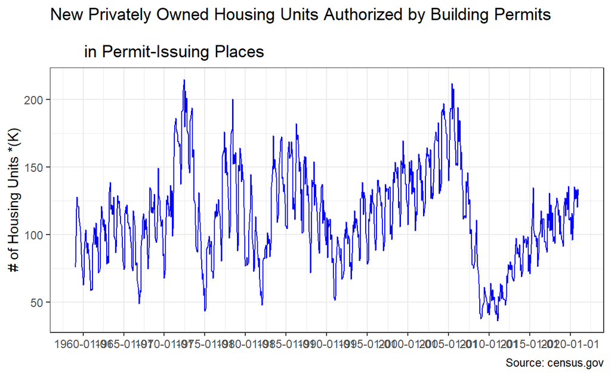

```r
permits %>% ggplot(aes(x=date,y=total)) +
  geom_line(color='blue') +
  labs(title = 'New Privately Owned Housing Units Authorized by Building Permits\n
       in Permit-Issuing Places', y='# of Housing Units *(K)', x= NULL, caption = 'Source: census.gov') +
  #theme(axis.text.x = element_text(angle = 45)) +
  scale_x_date(breaks = '5 years') +
  theme_bw()
```

The API for Neural Prophet (NP) I found is written for Python , so this study turns to reticulate , the r library to interact with Python in RMarkdown. Below are some resources if you’re interested :

- Github : https://rstudio.github.io/reticulate/
- RStudio video : https://docs.rstudio.com/tutorials/user/using-python-with-rstudio-and-reticulate/

## Using python

First , import the library , then check my anaconda environments (where I have python.exe) and finally choose the environment to use in this blog post

```r
library(reticulate)
conda_list()
```

```
                                             name
1                                        bayesian
2                                     everycheese
3                                     hellodjango
4 mlflow-6284a367a61b51ccdf445333a216776597fb4efc
5                                   neuralprophet
6                             virtualEnvTensorGPU
7                                virtualEnvTensor
                                                                                         python
1                                        C:\\ProgramData\\Anaconda3\\envs\\bayesian\\python.exe
2                                     C:\\ProgramData\\Anaconda3\\envs\\everycheese\\python.exe
3                                     C:\\ProgramData\\Anaconda3\\envs\\hellodjango\\python.exe
4 C:\\ProgramData\\Anaconda3\\envs\\mlflow-6284a367a61b51ccdf445333a216776597fb4efc\\python.exe
5                                   C:\\ProgramData\\Anaconda3\\envs\\neuralprophet\\python.exe
6                             C:\\ProgramData\\Anaconda3\\envs\\virtualEnvTensorGPU\\python.exe
7            C:\\Users\\pablo\\AppData\\Local\\conda\\conda\\envs\\virtualEnvTensor\\python.exe
```

```r
use_condaenv('neuralprophet')
```

The data for the algorithm needs to be prepared (it wants the date on a column named ds and the variable to forecast in y).

```python
permits_total = r.permits[['date','total']].rename(columns={'date':'ds','total':'y'})
```

I also create a train and test set with the intent of measuring the predictive capability of NP in data the model hasn’t seen

## Train and test

One can also choose to create them based on holding out a part of the time series for testing

```python
test_size = 120
train_df = permits_total[:-test_size]
test_df = permits_total[-test_size:]
train_df.head()
```

```
           ds      y
0  1959-01-01   75.7
1  1959-02-01   79.0
2  1959-03-01  119.0
3  1959-04-01  127.9
4  1959-05-01  120.8
```

## Import NeuralProphet

```python
from neuralprophet import NeuralProphet
```

## Fit the model on training data

Here’s where NP trains the model, since this is meant to evaluate the Neural Prophet , I choose the defaults. Perhaps in other blogs there can be a deep dive and tuning.

```python
m = NeuralProphet()
train_fit = m.fit(train_df,freq='MS')
```

[output not shown]

[output cut: 66 more lines]

[output not shown]

```python
train_fit.tail()
```

```
    SmoothL1Loss        MAE  RegLoss
46      0.019637  25.322689      0.0
47      0.019031  25.021062      0.0
48      0.018476  24.525203      0.0
49      0.018019  24.121631      0.0
50      0.017810  24.023309      0.0
```

#### Side note

But a different method to obtain train and test was used here.

### (Fit) Validation metrics

```python
val_metrics = m.test(test_df)
val_metrics
```

```
   SmoothL1Loss        MAE
0      0.018507  24.429792
```

These are the metrics provided by the API for the fit , however , below , a presentation of the author’s method for calculating the holdout forecast accuracy based on own work and experience.

## Alternative way to validate

Create a test dataset starting from the end of training and predict using the trained model

*Note : Had to use the m.make_future_dataframe as it creates its own structure to send to predict*

```python
future = m.make_future_dataframe(train_df, periods=120)
future.head()
```

```
          ds     y         t y_scaled
0 2011-02-01  None  1.001632      NaN
1 2011-03-01  None  1.003106      NaN
2 2011-04-01  None  1.004739      NaN
3 2011-05-01  None  1.006318      NaN
4 2011-06-01  None  1.007950      NaN
```

```python
holdout_fcst = m.predict(future)
```

## Plot the predictions

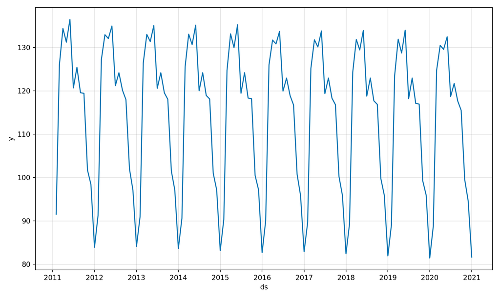

```python
m.plot(holdout_fcst);
plt.show()
```

### Now a dataset with the acutals and forecasts is created to measure accuracy

```python
df_final = pd.merge(permits_total, holdout_fcst[['ds','yhat1']], on='ds', how='left')
df_final.tail()
```

```
            ds      y       yhat1
740 2020-09-01  133.3  117.671341
741 2020-10-01  132.9  115.515945
742 2020-11-01  120.0   99.538391
743 2020-12-01  133.6   94.645309
744 2021-01-01  128.8   81.659882
```

```python
df_final['abs_error'] = abs(df_final['y']-df_final['yhat1'])
df_final.tail()
```

```
            ds      y       yhat1  abs_error
740 2020-09-01  133.3  117.671341  15.628659
741 2020-10-01  132.9  115.515945  17.384055
742 2020-11-01  120.0   99.538391  20.461609
743 2020-12-01  133.6   94.645309  38.954691
744 2021-01-01  128.8   81.659882  47.140118
```

SMAPE is used but evidently other measures can be similarly be calculated

```r
py$df_final %>% as_tibble() %>% rename(actuals=y,forecasts=yhat1) %>%
  mutate(ds = ymd(as.Date(ds))) %>%
  filter(!is.na(abs_error)) %>%
  filter(ds>ymd('2020-01-01')) %>%
  summarise(across(-ds,sum)) %>%
  mutate(avg_act_fcst = (actuals+forecasts)/2,
         smape = abs_error/avg_act_fcst,
         accuracy = percent(1-smape,accuracy = 0.01) )
```

```
# A tibble: 1 x 6
  actuals forecasts abs_error avg_act_fcst smape accuracy
    <dbl>     <dbl>     <dbl>        <dbl> <dbl> <chr>
1   1451.     1356.      249.        1403. 0.178 82.24%
```

### Plot of actuals and forecasts

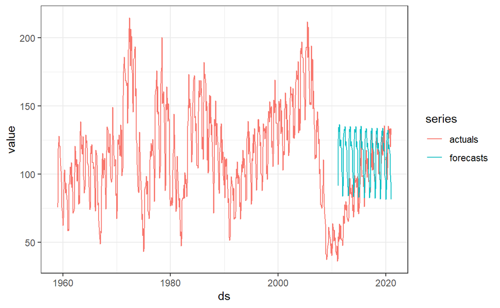

```r
py$df_final %>% as_tibble() %>% rename(actuals=y,forecasts=yhat1) %>%
  pivot_longer(cols = c(actuals,forecasts), names_to = 'series') %>%
  ggplot(aes(ds,value,color=series)) + geom_line() + theme_bw()
```

It is clear that just using past history it would have been (and still is) hard to accurately predict the rather noticeable growth in permits even in the midst of a pandemic

## Predict one year into the future

```python
future = m.make_future_dataframe(permits_total, periods=12)
forecast = m.predict(future)
```

## Plot the predictions

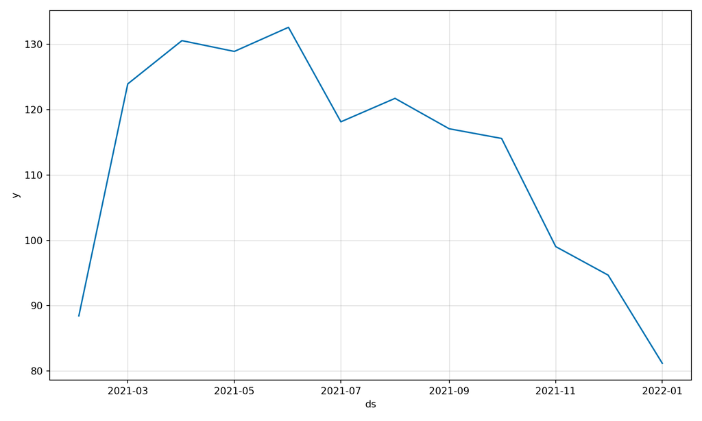

```python
m.plot(forecast);
plt.show()
```

It’s also possible to do the plot in R by referencing the forecast object with py$forecast

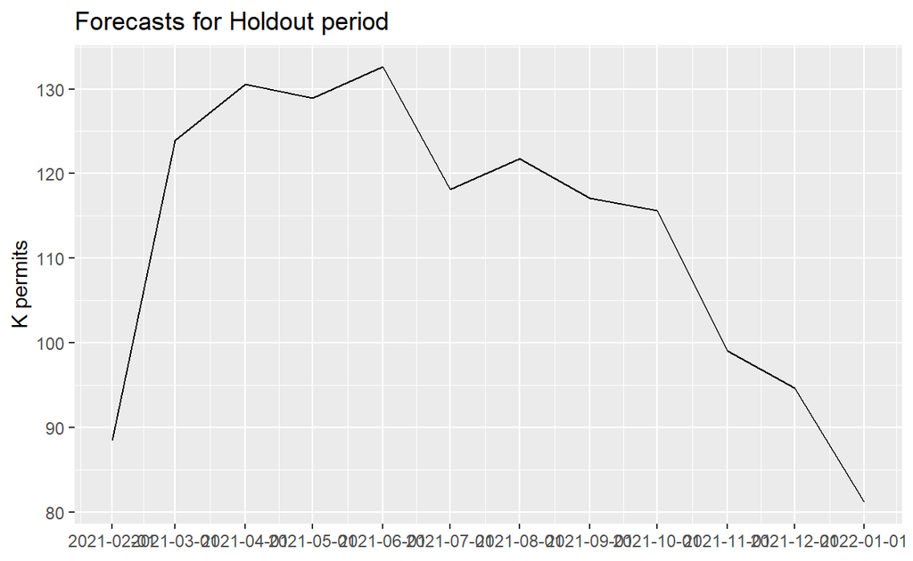

```r
py$forecast %>% as_tibble() %>% mutate(ds = as.Date(ds)) %>%
  ggplot(aes(ds,yhat1)) + geom_line() + scale_x_date(breaks = '1 month') +
  labs(title = 'Forecasts for Holdout period' , y='K permits', x=NULL)
```

There are some nice features from the library (quite similar if not identical than the ones from Facebook prophet’s api)

These are the time series components .

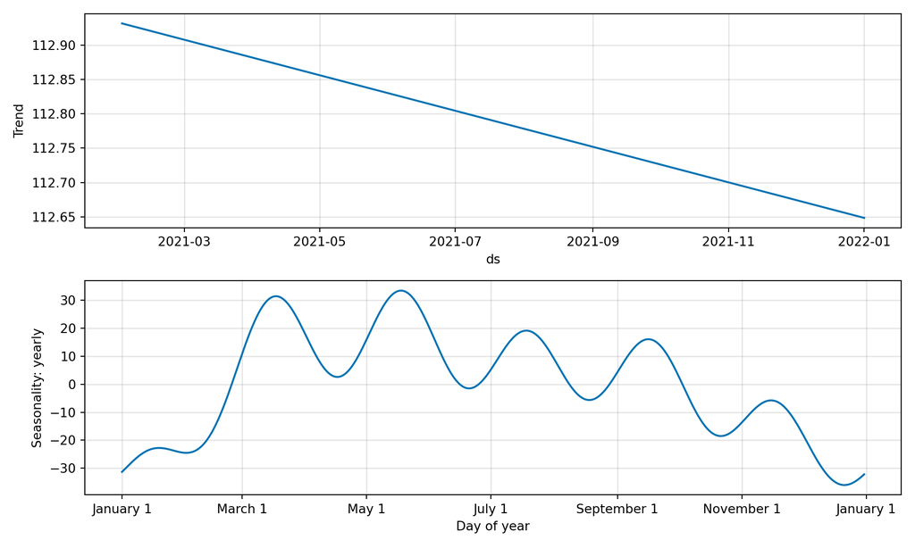

```python
m.plot_components(forecast);
plt.show()
```

And the parameters of the fit can also be displayed

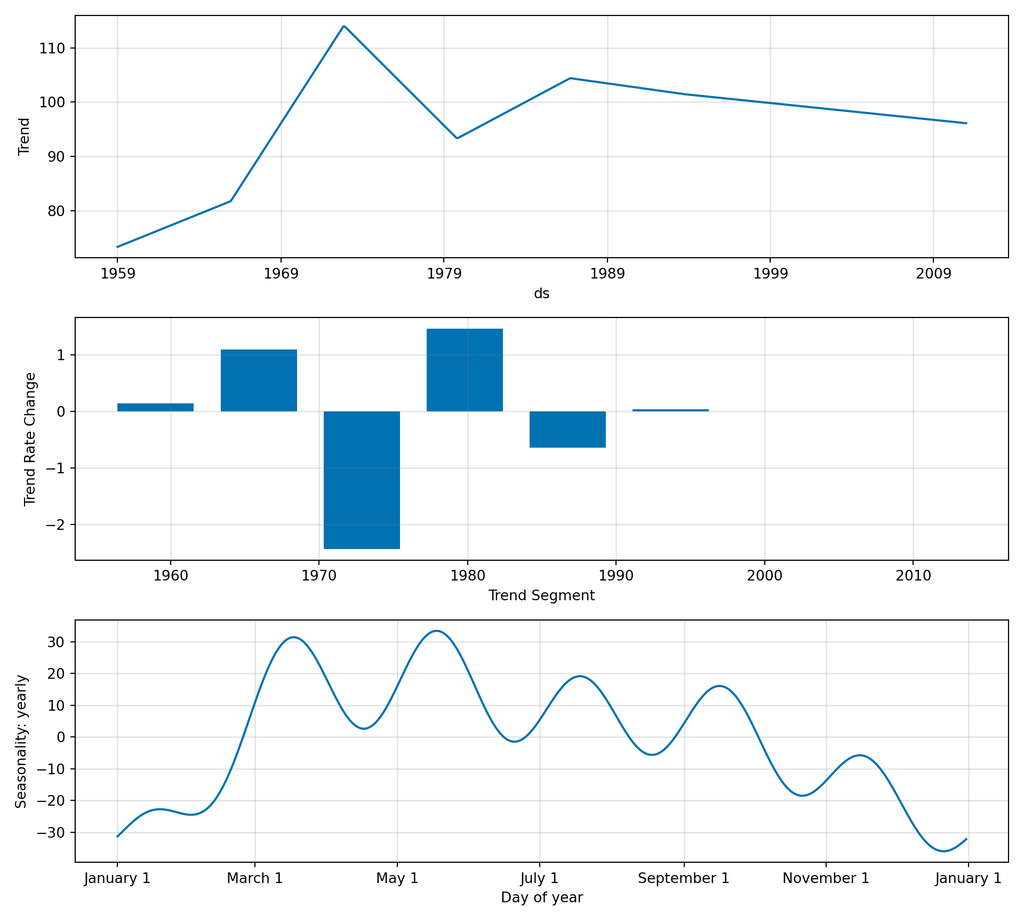

```python
m.plot_parameters();
plt.show()
```

I really enjoyed creating this notebook and experimenting with NeuralProphet , I hope you do to , please reach out with comments and feedback if you share the interest in forecasting.